# Leukemia reference cell typing

Eric Wafula

2025

### Objective

Creating as cell type annotation mapping file to utilize for the [cell-typing module](https://github.com/ewafula/scPhylogenomics/tree/main/analyses/cell-typing) of Leukemia datasets using [Single-cell Transcriptional Atlas of Human Hematopoiesis](https://aacrjournals.org/bloodcancerdiscov/article/6/4/307/763153/Single-cell-Transcriptional-Atlas-of-Human) the provided reference [symphony R object](https://bonemarrowmap.s3.us-east-2.amazonaws.com/BoneMarrowMap_Annotated_Dataset_expandedFeatures.rds)

### Libraries

```r
# Load libraries
suppressPackageStartupMessages(library(Seurat))
suppressPackageStartupMessages(library(tidyverse))
suppressPackageStartupMessages(library(symphony))
suppressPackageStartupMessages(library(ggpubr))
suppressPackageStartupMessages(library(patchwork))
suppressPackageStartupMessages(library(RColorBrewer))
suppressPackageStartupMessages(library(AUCell))
suppressPackageStartupMessages(library(doMC))
suppressPackageStartupMessages(library(BiocNeighbors))

# Install BoneMarrowMap package only if not already installed
if (!requireNamespace("BoneMarrowMap", quietly = TRUE)) {
  invisible(
    capture.output(
      suppressMessages(
        suppressWarnings(
          devtools::install_github("andygxzeng/BoneMarrowMap", quiet = TRUE)
        )
      )
    )
  )
  message("BoneMarrowMap installed successfully")
} else {
  message("BoneMarrowMap is already installed. Skipping installation.")
}
suppressPackageStartupMessages(library(BoneMarrowMap))
```

### Download bone marrow leukemia cell atlas reference objects

```r
# Set directory to store projection reference files
projection_path = file.path("..", "analyses", "cell-typing", "inputs")

# Make sure directory exists
if (!dir.exists(projection_path)) {
  dir.create(projection_path, recursive = TRUE)
}

# Paths for the three reference files
bm_ref_symphony_file <- file.path(projection_path, "BoneMarrowMap_SymphonyReference.rds")
bm_uwot_file <- file.path(projection_path, "BoneMarrowMap_uwot_model.uwot")


# Download Symphony Reference if not already present (~344 Mb) - for mapping
if (!file.exists(bm_ref_symphony_file)) {
  message("Downloading Symphony Reference...")
  curl::curl_download(
    "https://bonemarrowmap.s3.us-east-2.amazonaws.com/BoneMarrowMap_SymphonyReference.rds",
    destfile = bm_ref_symphony_file,
    quiet = FALSE
  )
} else {
  message("Symphony Reference already exists. Skipping download.")
}

# Download uwot model file if not already present (~221 Mb) - for UMAP projection
if (!file.exists(bm_uwot_file)) {
  message("Downloading uwot model file...")
  ccurl::curl_download(
    "https://bonemarrowmap.s3.us-east-2.amazonaws.com/BoneMarrowMap_uwot_model.uwot",
    destfile = bm_uwot_file,
    quiet = FALSE
  )
} else {
  message("uwot model file already exists. Skipping download.")
}

# Load Symphony reference object (for mapping)
ref <- readRDS(bm_ref_symphony_file)

# Set uwot path for UMAP projection
ref$save_uwot_path <- bm_uwot_file
```

### Visualize bone marrow leukemia reference cell altlas cell types

We are interested in broad cell type annotations - for granular cell type annotations use `group.by = 'CellType_Annotation_formatted'`

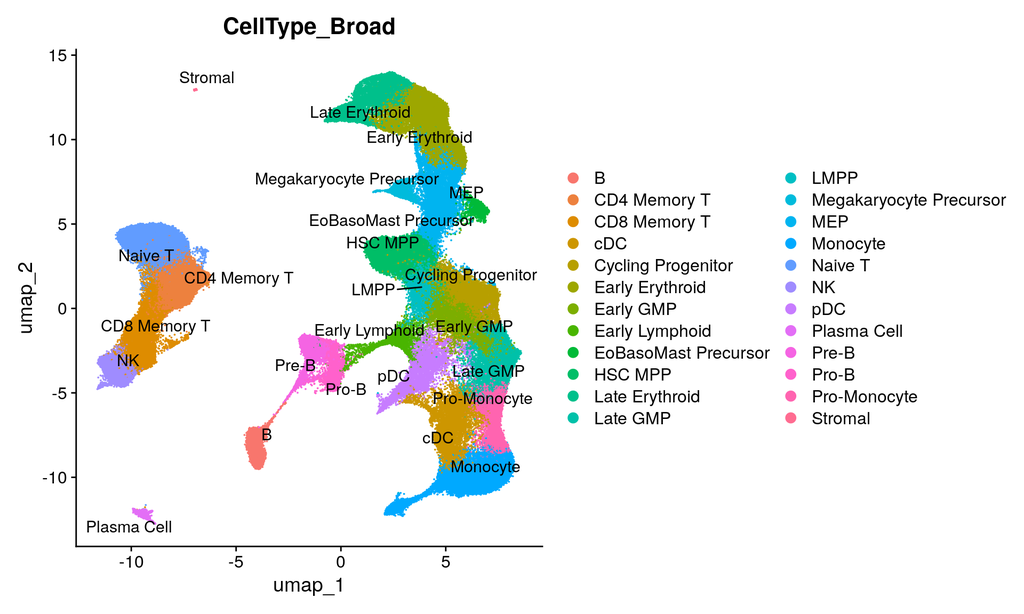

```r
# plot reference hematopoietic cell types
ReferenceSeuratObj <-  BoneMarrowMap::create_ReferenceObject(ref)
Seurat::DimPlot(ReferenceSeuratObj, reduction = 'umap', group.by = 'CellType_Broad',
                raster=FALSE, label=TRUE, label.size = 4, repel = TRUE)
```

### Load leukemia (AML) scRNA-Seq query dataset

```r
# create seurat object
seurat_object_path = file.path("..", "analyses", "cell-typing", "objects",
                               "AML", "AML-clusters.rds")
query <- readRDS(seurat_object_path)
query
```

```
An object of class Seurat
28240 features across 7572 samples within 1 assay
Active assay: RNA (28240 features, 2000 variable features)
 3 layers present: counts, data, scale.data
 2 dimensional reductions calculated: pca, umap
```

### Map the AML query dataset to the leukemia reference cell atlas

```r
# batch variable to correct in the query data, set as NULL if no batches in query
batchvar <- NULL

# Map query dataset using Symphony
query_mapped <- BoneMarrowMap::map_Query(
  exp_query = query@assays$RNA$counts,
  metadata_query = query@meta.data,
  ref_obj = ref,
  vars = batchvar,
  verbose = TRUE,
  do_normalize = TRUE,
  do_umap = TRUE
)
```

### Perform quality check for the query mapping

The distribution of mapping error scores can vary broadly from sample to sample. In this context, we will want to threshold outliers with high mapping error on a per-sample basis. Typically, a threshold of 2, 2.5, or 3 MADs MADs (Median Absolute Deviations), which are often used for QC filtering in single-cell (and bulk) RNA-seq pipelines, works well.

In some cases where sequencing depth is very low (e.g. older datasets from first-generation scRNA-seq protocols), a more stringent threshold of even 1.5 may be warranted to eliminate cells with low mapping quality

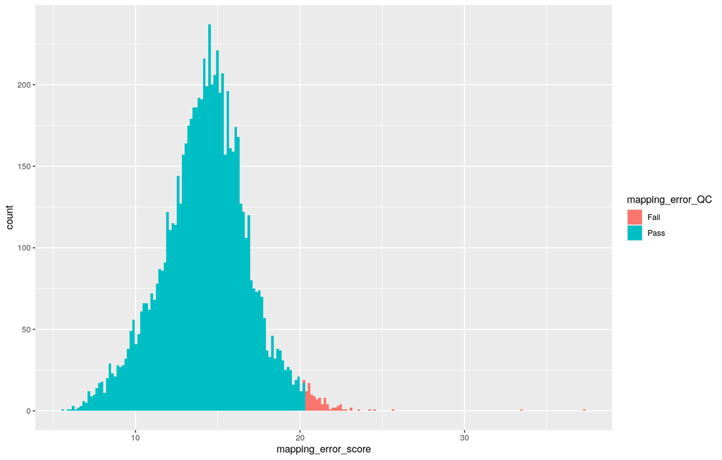

```r
# Run QC based on mapping error score, flag cells with mapping error >= 2.5 MADs above median
query_mapped <- query_mapped %>%
  BoneMarrowMap::calculate_MappingError(., reference = ref, MAD_threshold = 2.5)

# # Plot distribution by patient to ensure you are catching the tail
query_mapped@meta.data %>%
  ggplot(aes(x = mapping_error_score, fill = mapping_error_QC)) +
  geom_histogram(bins = 200)
```

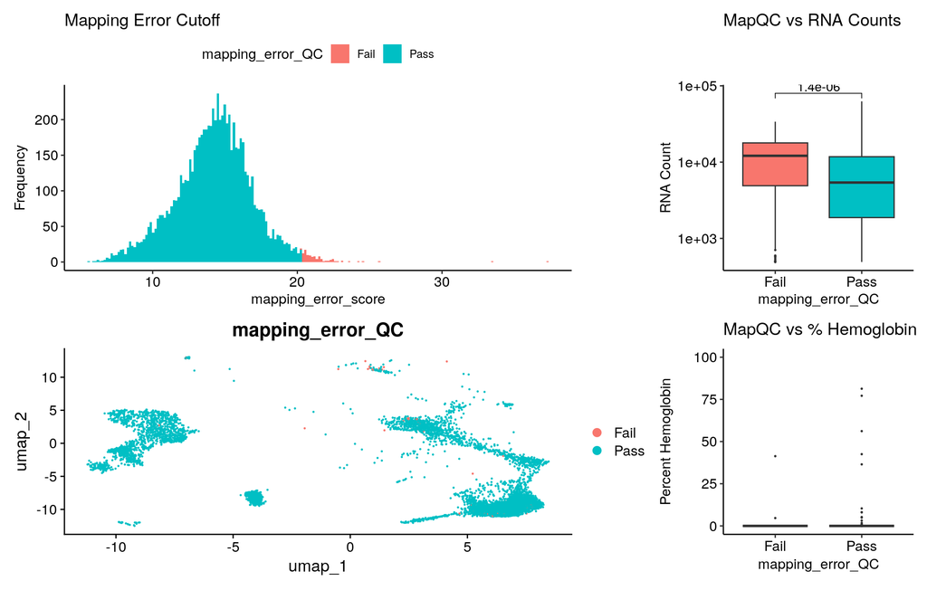

```r
# Get QC Plots
QC_plots <- plot_MappingErrorQC(query_mapped)

# Plot together - If this is too crowded,
patchwork::wrap_plots(QC_plots, ncol = 2, widths = c(0.8, 0.3, 0.8, 0.3))
```

Please adjust the MAD_threshold (typically between 1 and 3) based on the distribution of your dataset to identify the outliers with low quality and high mapping error scores. This will improve your classifications and any downstream composition analysis

Please adjust the MAD_threshold (typically between 1 and 3) based on the distribution of your dataset to identify the outliers with low quality and high mapping error scores. This will improve your classifications and any downstream composition analysis.The MAD threshold determines how aggressively outlier cells are filtered. Lower thresholds (e.g., 1–2 MADs) remove more cells and are appropriate for noisy or variable datasets where mis-mapping is common. Higher thresholds (e.g., 2.5–3 MADs) are more conservative, retaining most cells and excluding only extreme outliers, which is preferable for high-quality datasets. We recommend inspecting the QC metric distributions (e.g., gene counts, hemoglobin expression, mapping error scores) and starting with 2.5 MADs, then adjusting downwards if clear low-quality populations remain.

### Assign cell types to the query dataset

Use a KNN classifier to assign cell identity based on the 30 K-Nearest Neighbours from the reference map. Broader cell type labels will also be transferred automatically along with the precise cell type labels. - for granular cell type annotations use `group.by = 'predicted_CellType'`

```r
# Predict hematopoietic cell types by KNN classification
query_annotated <- BoneMarrowMap::predict_CellTypes(
  query_obj = query_mapped,
  ref_obj = ref,
  initial_label = 'initial_CellType', # celltype assignments before filtering on mapping QC
  final_label = 'predicted_CellType',  # celltype assignments with map QC failing cells assigned as NA
  include_broad = TRUE
)

# Replace NA annotations with "Unknown"
query_annotated@meta.data$predicted_CellType_Broad <- ifelse(
  is.na(query_annotated@meta.data$predicted_CellType_Broad),
  "Unknown",
  query_annotated@meta.data$predicted_CellType_Broad
)

# Double-check unique labels
unique(query_annotated@meta.data$predicted_CellType_Broad)
```

```
 [1] "B"                       "Monocyte"
 [3] "CD8 Memory T"            "CD4 Memory T"
 [5] "HSC MPP"                 "Naive T"
 [7] "Early GMP"               "Pro-Monocyte"
 [9] "NK"                      "LMPP"
[11] "cDC"                     "Unknown"
[13] "Late GMP"                "Stromal"
[15] "Pro-B"                   "Late Erythroid"
[17] "EoBasoMast Precursor"    "MEP"
[19] "Plasma Cell"             "Cycling Progenitor"
[21] "Early Lymphoid"          "pDC"
[23] "Early Erythroid"         "Megakaryocyte Precursor"
```

[output not shown]

### Visualize AML reference cell type assignments

- exclude outlier cells with high mapping error i.e., `Low-quality`

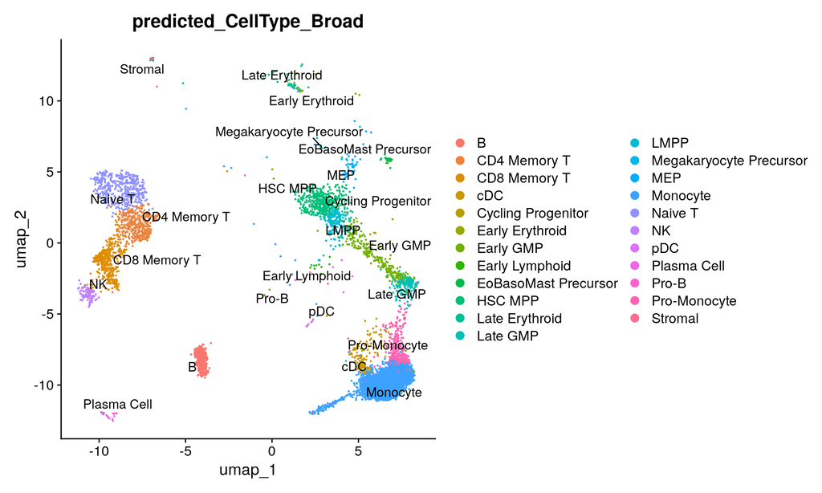

```r
DimPlot(subset(query_annotated, mapping_error_QC == 'Pass'),
        reduction = 'umap_projected', group.by = 'predicted_CellType_Broad',
        raster=FALSE, label=TRUE, label.size = 4, repel = TRUE)
```

### Genrate cell type mappings

```r
query_annotated@meta.data %>% dplyr::select(cell_id, predicted_CellType_Broad) %>%
  dplyr::rename(cell_type = predicted_CellType_Broad) %>%
  readr::write_tsv(file.path(projection_path, "AML-LE1-cell-annotation.tsv.gz"))
```